# Assignment2 – Regression

Brian Ritz

Friday, April 24, 2015

Dataset: Hollywood Movies

Objective:

1 Plot the independent variables X2, X3 X4 together in a single plot - what do you conclude in terms of relationship between them? 2 Scatter plot among the variables 3 ADF of the independent variables 4 Regression output - R2 and any other metric you want to mention 5 Regression coefficients 6 p-value of the coefficients 7 What can you comment about multicollinearity? 8 plot the ACF of the residuals

**1 Plot the independent variables X2, X3, and X4 together in a single plot - what do you conclude in terms of relationship between them?**

```r
library(tidyr) #data munging
library(dplyr) #data munging
```

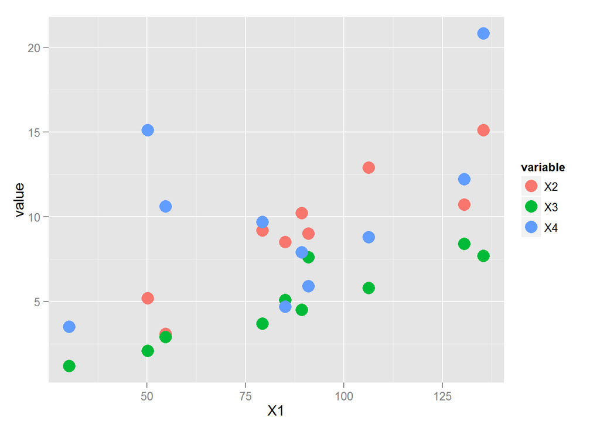

```r
library(ggplot2) #plotting
library(tseries) #adf.test
library(usdm) # vif
movie.dataset <- read.csv("mlr04.csv", header=T)
gather(movie.dataset, "variable","value", 2:4) %>%
  ggplot(aes(x=X1, y=value, col=variable)) + geom_point(size=5)
```

**2 Scatter plot among the variables**

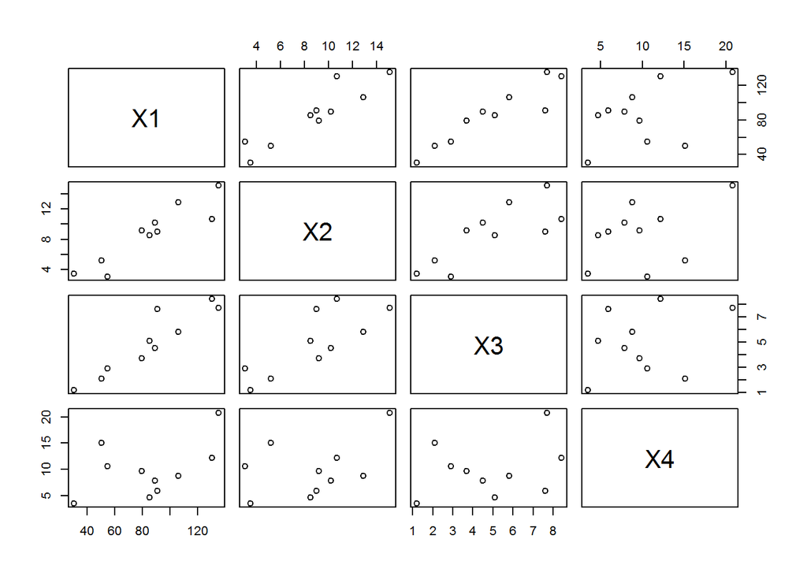

```r
plot(movie.dataset)
```

WHAT DO I SEE? X1, X2, and X3 all have positive relationships with each other. But X4 does not have as apparent positive relationship with either X1, X2, or X3.

**3 ADF of the independent variables**

```r
# X2
adf.test(movie.dataset$X2)
```

```
##
##  Augmented Dickey-Fuller Test
##
## data:  movie.dataset$X2
## Dickey-Fuller = -0.8326, Lag order = 2, p-value = 0.9452
## alternative hypothesis: stationary
```

```r
#X3
adf.test(movie.dataset$X3)
```

```
##
##  Augmented Dickey-Fuller Test
##
## data:  movie.dataset$X3
## Dickey-Fuller = -1.454, Lag order = 2, p-value = 0.7804
## alternative hypothesis: stationary
```

```r
#X4
adf.test(movie.dataset$X4)
```

```
##
##  Augmented Dickey-Fuller Test
##
## data:  movie.dataset$X4
## Dickey-Fuller = -10.7343, Lag order = 2, p-value = 0.01
## alternative hypothesis: stationary
```

**4 Regression output - R2 and any other metric you want to mention**

```r
summary(model <- lm(X1~X2+X3+X4, data=movie.dataset, y=T, x=T))
```

```
##
## Call:
## lm(formula = X1 ~ X2 + X3 + X4, data = movie.dataset, x = T,
##     y = T)
##
## Residuals:
##      Min       1Q   Median       3Q      Max
## -12.4384  -3.1695   0.8499   3.5134   9.6207
##
## Coefficients:
##             Estimate Std. Error t value Pr(>|t|)
## (Intercept)   7.6760     6.7602   1.135   0.2995
## X2            3.6616     1.1178   3.276   0.0169 *
## X3            7.6211     1.6573   4.598   0.0037 **
## X4            0.8285     0.5394   1.536   0.1754
## ---
## Signif. codes:  0 '***' 0.001 '**' 0.01 '*' 0.05 '.' 0.1 ' ' 1
##
## Residual standard error: 7.541 on 6 degrees of freedom
## Multiple R-squared:  0.9668, Adjusted R-squared:  0.9502
## F-statistic: 58.22 on 3 and 6 DF,  p-value: 7.913e-05
```

The R-squared is .96, which is relatively high. You can interpret this as the model explains 96% of the variation in X1 through variation in the independent variables. The F-statistic has a small p-value, indicating that the model fits the data well.

**5 Regression coefficients**

```r
model$coefficients
```

```
## (Intercept)          X2          X3          X4
##   7.6760285   3.6616040   7.6210513   0.8284681
```

The coefficients can be interpreted in the following way: for a one unit increase in the independent variable, the dependent variable will change by the coefficient on the independent variable. For example, for a one unit increase in X2, X1 will increase by 3.66; for a one unit increase in X3, X1 will increase 7.62; and for a one unit increase in X4, X1 will increase by .82.

**6 p-value of the coefficients**

```r
a<-summary(model)
a$coefficients
```

```
##              Estimate Std. Error  t value    Pr(>|t|)
## (Intercept) 7.6760285  6.7602276 1.135469 0.299491477
## X2          3.6616040  1.1177514 3.275866 0.016909724
## X3          7.6210513  1.6573172 4.598426 0.003698129
## X4          0.8284681  0.5393591 1.536023 0.175439839
```

The coefficients fro X2 and X3 are significant at alpha=.05, wile X4 is only significant at alpha=.2. The coefficient for the intercept has a p-value of .29. You can interpret these p-values as the probability that a process with actual mean coefficient = 0 would produce these data.

**7 What can you comment about multicollinearity?**

```r
cor(movie.dataset[2:4])
```

```
##           X2        X3        X4
## X2 1.0000000 0.7899575 0.4291329
## X3 0.7899575 1.0000000 0.2987612
## X4 0.4291329 0.2987612 1.0000000
```

```r
vif(movie.dataset[2:4])
```

```
##   Variables      VIF
## 1        X2 2.984943
## 2        X3 2.673920
## 3        X4 1.232227
```

**8 plot the ACF of the residuals**

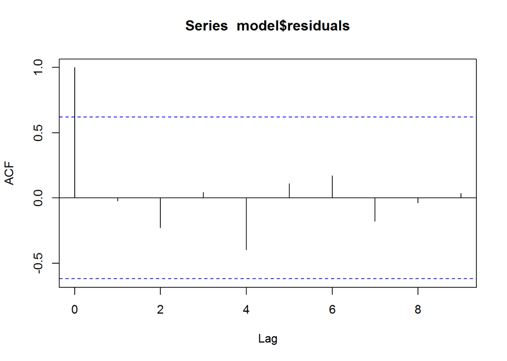

```r
acf(model$residuals)
```

Testing the auto-correlation of residuals. There are no lags that are outside the confidence band for acf=0, so we can conclude that auto-correlation is not present.